# Exploratory Data Analysis with Seaborn (Movies Dataset)

This notebook contains exploratory data analysis and visualizations using Seaborn for the movies dataset provided by vega datasets. The movies set contains nearlty 3200 movies and information about their budgets, profits, release dates, genres, and ratings. There is a significant amount of missing information in this dataset, so only rows with compete data once unused columns are removed will be considered.

The analysis below was used to make sense of the data set and provide a visually dynammic exploration of the data.

```python
import numpy as np
import pandas as pd

import matplotlib as mpl
import matplotlib.pyplot as plt
import seaborn as sns
from vega_datasets import data
```

```python
movies = data.movies()
```

```python
movies.head()
```

|  | Title | US_Gross | Worldwide_Gross | US_DVD_Sales | Production_Budget | Release_Date | MPAA_Rating | Running_Time_min | Distributor | Source | Major_Genre | Creative_Type | Director | Rotten_Tomatoes_Rating | IMDB_Rating | IMDB_Votes |
| --- | --- | --- | --- | --- | --- | --- | --- | --- | --- | --- | --- | --- | --- | --- | --- | --- |
| 0 | The Land Girls | 146083.0 | 146083.0 | NaN | 8000000.0 | Jun 12 1998 | R | NaN | Gramercy | None | None | None | None | NaN | 6.1 | 1071.0 |
| 1 | First Love, Last Rites | 10876.0 | 10876.0 | NaN | 300000.0 | Aug 07 1998 | R | NaN | Strand | None | Drama | None | None | NaN | 6.9 | 207.0 |
| 2 | I Married a Strange Person | 203134.0 | 203134.0 | NaN | 250000.0 | Aug 28 1998 | None | NaN | Lionsgate | None | Comedy | None | None | NaN | 6.8 | 865.0 |
| 3 | Let's Talk About Sex | 373615.0 | 373615.0 | NaN | 300000.0 | Sep 11 1998 | None | NaN | Fine Line | None | Comedy | None | None | 13.0 | NaN | NaN |
| 4 | Slam | 1009819.0 | 1087521.0 | NaN | 1000000.0 | Oct 09 1998 | R | NaN | Trimark | Original Screenplay | Drama | Contemporary Fiction | None | 62.0 | 3.4 | 165.0 |

```python
movies.describe()
```

|  | US_Gross | Worldwide_Gross | US_DVD_Sales | Production_Budget | Running_Time_min | Rotten_Tomatoes_Rating | IMDB_Rating | IMDB_Votes |
| --- | --- | --- | --- | --- | --- | --- | --- | --- |
| count | 3.194000e+03 | 3.194000e+03 | 5.640000e+02 | 3.200000e+03 | 1209.000000 | 2321.000000 | 2988.000000 | 2988.000000 |
| mean | 4.400209e+07 | 8.534340e+07 | 3.490155e+07 | 3.106917e+07 | 110.193548 | 54.336924 | 6.283467 | 29908.644578 |
| std | 6.255531e+07 | 1.499473e+08 | 4.589512e+07 | 3.558591e+07 | 20.171014 | 28.076593 | 1.252290 | 44937.582335 |
| min | 0.000000e+00 | 0.000000e+00 | 6.184540e+05 | 2.180000e+02 | 46.000000 | 1.000000 | 1.400000 | 18.000000 |
| 25% | 5.493221e+06 | 8.031285e+06 | 9.906211e+06 | 6.575000e+06 | 95.000000 | 30.000000 | 5.600000 | 4828.500000 |
| 50% | 2.201947e+07 | 3.116893e+07 | 2.033156e+07 | 2.000000e+07 | 107.000000 | 55.000000 | 6.400000 | 15106.000000 |
| 75% | 5.609176e+07 | 9.728380e+07 | 3.779422e+07 | 4.200000e+07 | 121.000000 | 80.000000 | 7.200000 | 35810.500000 |
| max | 7.601676e+08 | 2.767891e+09 | 3.525821e+08 | 3.000000e+08 | 222.000000 | 100.000000 | 9.200000 | 519541.000000 |

```python
movies.info()
```

```
<class 'pandas.core.frame.DataFrame'>
RangeIndex: 3201 entries, 0 to 3200
Data columns (total 16 columns):
 #   Column                  Non-Null Count  Dtype
---  ------                  --------------  -----
 0   Title                   3200 non-null   object
 1   US_Gross                3194 non-null   float64
 2   Worldwide_Gross         3194 non-null   float64
 3   US_DVD_Sales            564 non-null    float64
 4   Production_Budget       3200 non-null   float64
 5   Release_Date            3201 non-null   object
 6   MPAA_Rating             2596 non-null   object
 7   Running_Time_min        1209 non-null   float64
 8   Distributor             2969 non-null   object
 9   Source                  2836 non-null   object
 10  Major_Genre             2926 non-null   object
 11  Creative_Type           2755 non-null   object
 12  Director                1870 non-null   object
 13  Rotten_Tomatoes_Rating  2321 non-null   float64
 14  IMDB_Rating             2988 non-null   float64
 15  IMDB_Votes              2988 non-null   float64
dtypes: float64(8), object(8)
memory usage: 400.2+ KB
```

# Null Values

The data contained a large amount of missing data, but there are several columns we are not interested in for the purpose of this analysis. After we have filtered the data to only contain the columns we want to look at, we can remove the null values in the remaining columns and still retain a large portion of the data. Removing null values will be important in continuing the analysis past the exploratory phase.

```python
movies.isna().sum()
```

```
Title                        1
US_Gross                     7
Worldwide_Gross              7
US_DVD_Sales              2637
Production_Budget            1
Release_Date                 0
MPAA_Rating                605
Running_Time_min          1992
Distributor                232
Source                     365
Major_Genre                275
Creative_Type              446
Director                  1331
Rotten_Tomatoes_Rating     880
IMDB_Rating                213
IMDB_Votes                 213
dtype: int64
```

```python
movies = movies[["Title", "US_Gross", "Worldwide_Gross", "Production_Budget", "Release_Date", "Distributor",
                "Source", "Major_Genre", "Creative_Type", "Rotten_Tomatoes_Rating", "IMDB_Rating", "IMDB_Votes"]]
```

```python
len(movies["Title"])
```

```
3201
```

```python
movies = movies.dropna(inplace = False)
len(movies["Title"])
```

```
2019
```

```python
movies.info()
```

```
<class 'pandas.core.frame.DataFrame'>
Int64Index: 2019 entries, 4 to 3200
Data columns (total 12 columns):
 #   Column                  Non-Null Count  Dtype
---  ------                  --------------  -----
 0   Title                   2019 non-null   object
 1   US_Gross                2019 non-null   float64
 2   Worldwide_Gross         2019 non-null   float64
 3   Production_Budget       2019 non-null   float64
 4   Release_Date            2019 non-null   object
 5   Distributor             2019 non-null   object
 6   Source                  2019 non-null   object
 7   Major_Genre             2019 non-null   object
 8   Creative_Type           2019 non-null   object
 9   Rotten_Tomatoes_Rating  2019 non-null   float64
 10  IMDB_Rating             2019 non-null   float64
 11  IMDB_Votes              2019 non-null   float64
dtypes: float64(6), object(6)
memory usage: 205.1+ KB
```

# Histograms

To better understand variable distribution, we can plot histograms to show how the values of each quantitative variable are distributed among the data points. In viewing the histogram plots below, we can see that most of the variables are skewed (with the exception of IMDB rating), which can be fixed with a log transformation.

```python
quant_variables = movies.describe()
quant_variables
```

|  | US_Gross | Worldwide_Gross | Production_Budget | Rotten_Tomatoes_Rating | IMDB_Rating | IMDB_Votes |
| --- | --- | --- | --- | --- | --- | --- |
| count | 2.019000e+03 | 2.019000e+03 | 2.019000e+03 | 2019.000000 | 2019.000000 | 2019.000000 |
| mean | 5.400199e+07 | 1.047255e+08 | 3.847044e+07 | 52.684993 | 6.260327 | 35009.770183 |
| std | 6.532612e+07 | 1.615721e+08 | 3.727537e+07 | 27.697821 | 1.219196 | 46331.008490 |
| min | 0.000000e+00 | 0.000000e+00 | 1.500000e+04 | 1.000000 | 1.600000 | 25.000000 |
| 25% | 1.304805e+07 | 1.599422e+07 | 1.300000e+07 | 28.000000 | 5.500000 | 7882.000000 |
| 50% | 3.324468e+07 | 4.618957e+07 | 2.700000e+07 | 53.000000 | 6.400000 | 20268.000000 |
| 75% | 6.901676e+07 | 1.289106e+08 | 5.200000e+07 | 78.000000 | 7.100000 | 42448.500000 |
| max | 7.601676e+08 | 2.767891e+09 | 3.000000e+08 | 100.000000 | 9.200000 | 519541.000000 |

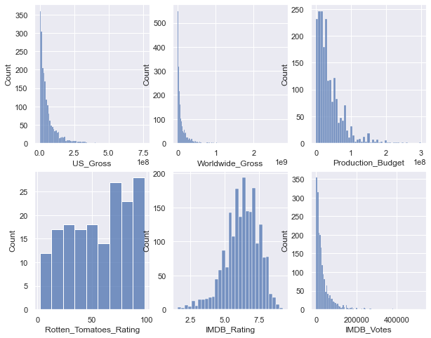

```python
fig = plt.figure(figsize=(10, 8))
sns.set_theme()

plt.subplot(2,3,1)
sns.histplot(data = movies, x = "US_Gross")

plt.subplot(2,3,2)
sns.histplot(data = movies, x = "Worldwide_Gross")

plt.subplot(2,3,3)
sns.histplot(data = movies, x = "Production_Budget")

plt.subplot(2,3,4)
sns.histplot(data = movies2, x = "Rotten_Tomatoes_Rating")

plt.subplot(2,3,5)
sns.histplot(data = movies, x = "IMDB_Rating")

plt.subplot(2,3,6)
sns.histplot(data = movies, x = "IMDB_Votes")
```

# Correlation

To see how the quantitative variables are correlated with each other, we can use a correlation plot, which displays a matrix containing the correlation among all the variables. This is important for future modeling, since it is helpful to know that input variables are correlated with the response and whether there is cross correlation among the inputs.

[figure not shown]

```python
corr = movies.corr().stack().reset_index(name = "correlation")

corr_plot = sns.relplot(data = corr, x = "level_0", y = "level_1", hue = "correlation", size = "correlation",
    palette="YlOrBr", aspect = 2.5, hue_norm = (-1, 1))
```

# Pairplot

For a complete view of the relationship among qualitative variables and their distributions, we can create a pairplot, which visualizes the correlations in the form of a scatter plot. In the second pair plot, the scatter plots below the diagonal are displayed as density plots.

[figure not shown]

```python
sns.pairplot(movies)
```

[figure not shown]

```python
pair = sns.pairplot(movies)
pair.map_lower(sns.kdeplot, fill = True)
```

# Qualitative Variables

The sections below attempt to make sense of the quantitative variables in this data set. In the first plot below containing the Pair Grid, we have grouped the movies by distribution company and sorted them by US Gross Profit. The plots to the right show how the remaining quantitative variables relate to distribtution companies sorted by profit. The plot shows that the most prolific distributors make movies with the highest budgets that make the most money. However, that doesn't always translate to the best movies, as Rotten Tomato Ratings and IMDB ratings are distributed more evenly across production companies.

The second plot shows how movie genre relates to the log transform of US Gross Profit. The graph shows that Action movies are the highest grossing genre, while Documentary is the lowest grossing.

Plot Three shows the distribution of US Gross Profit grouped by release month. The plot shows that the summer months and holiday season have a wider range of profit values with high grossing films.

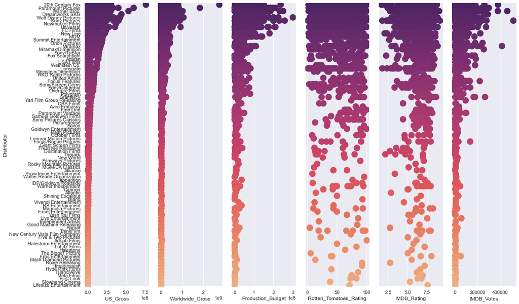

```python
pair = sns.PairGrid(movies.sort_values("US_Gross", ascending = False), x_vars = quant_variables.columns,
                    y_vars = ["Distributor"], height = 10, aspect = .25)

pair.map(sns.stripplot, size = 15, orient = "h", jitter = False, palette = "flare_r")
```

[figure not shown]

```python
fig = plt.figure(figsize = (10, 5))
sns.histplot(movies2, x = "US_Gross", hue = "Major_Genre", multiple = "stack", palette = "flare_r", edgecolor = ".3",
    linewidth = .5, log_scale = True,)
```

```python
def split_date(row):
     return row.split(" ")[0]

movies["Month"] = movies.apply(lambda row: split_date(row["Release_Date"]), axis = 1)
movies_by_month = movies.groupby(["Month"]).mean()
movies_by_month
```

| Month | US_Gross | Worldwide_Gross | Production_Budget | Rotten_Tomatoes_Rating | IMDB_Rating | IMDB_Votes |
| --- | --- | --- | --- | --- | --- | --- |
| Apr | 3.494843e+07 | 5.798873e+07 | 3.054760e+07 | 45.808219 | 6.021233 | 25134.815068 |
| Aug | 4.124302e+07 | 7.204292e+07 | 3.315266e+07 | 47.251366 | 5.985792 | 29433.568306 |
| Dec | 6.332816e+07 | 1.267359e+08 | 4.117953e+07 | 64.500000 | 6.806923 | 42000.134615 |
| Feb | 4.593310e+07 | 7.572799e+07 | 3.326385e+07 | 40.976923 | 5.926154 | 27643.330769 |
| Jan | 3.575706e+07 | 5.274772e+07 | 2.744744e+07 | 35.935897 | 5.616667 | 20527.217949 |
| Jul | 7.846865e+07 | 1.627523e+08 | 5.125573e+07 | 56.843373 | 6.327711 | 44791.204819 |
| Jun | 8.281089e+07 | 1.658407e+08 | 5.218968e+07 | 57.573864 | 6.263068 | 41568.193182 |
| Mar | 4.684260e+07 | 8.543986e+07 | 3.633750e+07 | 48.105263 | 5.992763 | 32004.671053 |
| May | 8.915730e+07 | 2.021636e+08 | 5.720961e+07 | 49.430657 | 6.158394 | 46026.226277 |
| Nov | 6.345787e+07 | 1.341136e+08 | 4.545690e+07 | 58.331633 | 6.454082 | 35028.173469 |
| Oct | 2.933814e+07 | 5.050623e+07 | 2.455841e+07 | 54.953704 | 6.401389 | 33925.203704 |
| Sep | 3.041612e+07 | 4.914290e+07 | 2.627955e+07 | 51.284916 | 6.322905 | 30161.441341 |

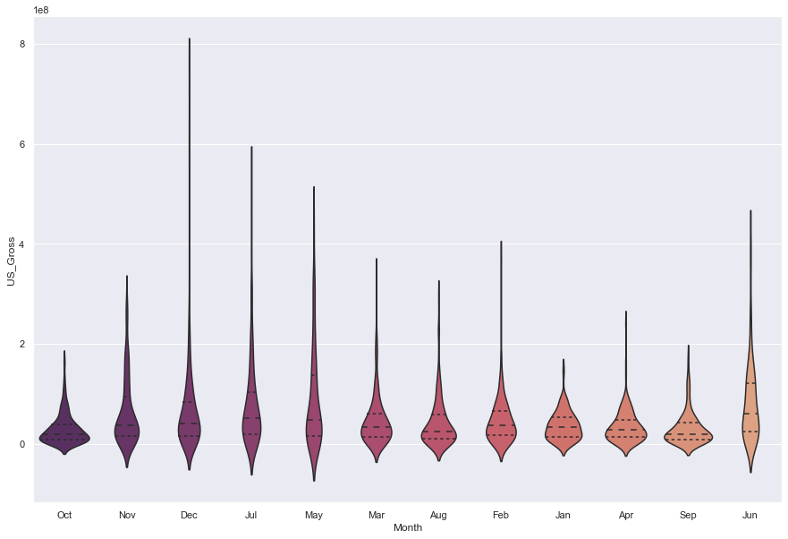

```python
fig = plt.figure(figsize=(15, 10))
sns.violinplot(data = movies, x = "Month", y = "US_Gross", inner = "quart", palette = "flare_r")
```

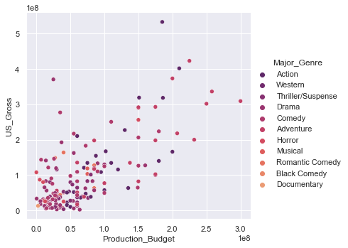

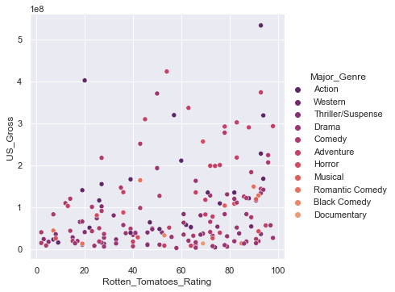

```python
fig = plt.figure(figsize=(10, 5))

sns.relplot(data = movies2, x = "Production_Budget", y = "US_Gross", hue = "Major_Genre", sizes=(40, 400),
            palette = "flare_r")

sns.relplot(data = movies2, x = "Rotten_Tomatoes_Rating", y = "US_Gross", hue = "Major_Genre", sizes=(40, 400),
            palette = "flare_r")
```